# 5th_Assignment

Tarun BT

2025-03-31

Q1-A. Normalization: K-Means is sensitive to feature scaling. Normalizing the data set ensures that attributes with larger scales (e.g., Pro-line) don’t dominate the clustering process.

Choosing k: The number of clusters affects how well the data is grouped. Methods like the Elbow Method (using WSS - Within-Cluster Sum of Squares) and Silhouette Score help determine an optimal k.

Loading necessary library files.

```r
library(tidyverse)
```

```r
library(ggplot2)
library(factoextra)
library(cluster)
library(fpc)
library(dbscan)
```

Loading the data set

```r
wine <- read.csv("C:\\Users\\Tarun\\OneDrive\\Desktop\\R program\\5th_Assignment\\wine-clustering.csv")
```

Normalize data to ensure fair clustering

```r
wines.norm <- scale(wine)
```

Determine optimal k using WSS (Elbow Method)

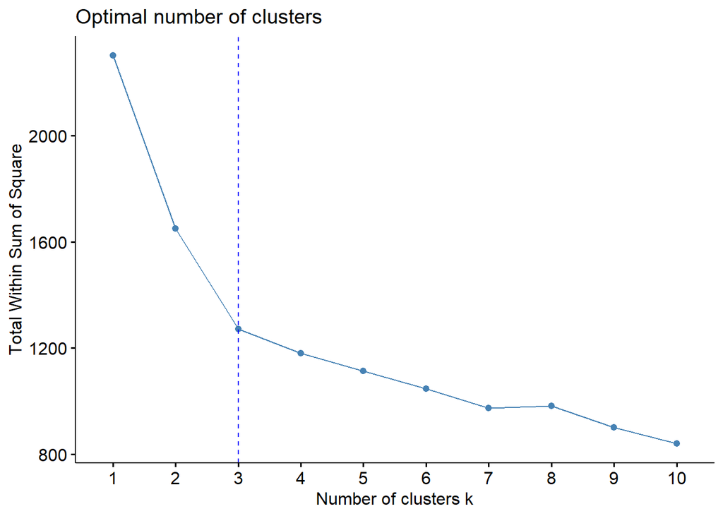

```r
fviz_nbclust(wines.norm, kmeans, method = "wss") +  # Visualize elbow method
geom_vline(xintercept = 3 , linetype="dashed", color="blue")
```

Determine optimal k using Silhouette Method

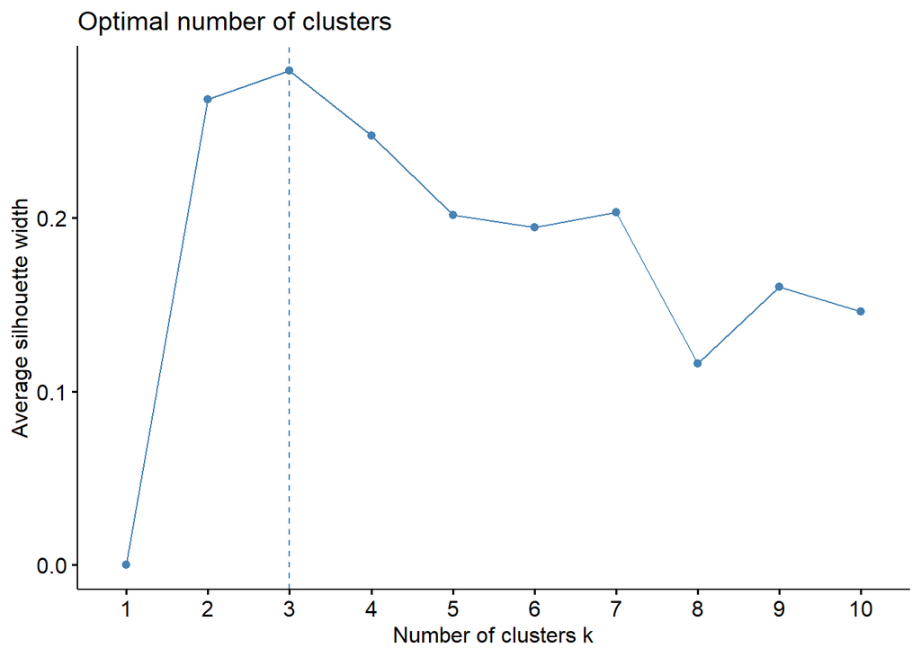

```r
fviz_nbclust(wines.norm, kmeans, method = "silhouette")  # Evaluate cluster quality
```

Q1-B.

```r
set.seed(123)  # Set seed for reproducibility
k_optimal <- 3  # Set based on WSS & Silhouette results
```

Perform K-Means clustering

```r
kmeans.wines <- kmeans(wines.norm, centers = k_optimal, nstart = 25)
```

Visualize clusters formed by K-Means

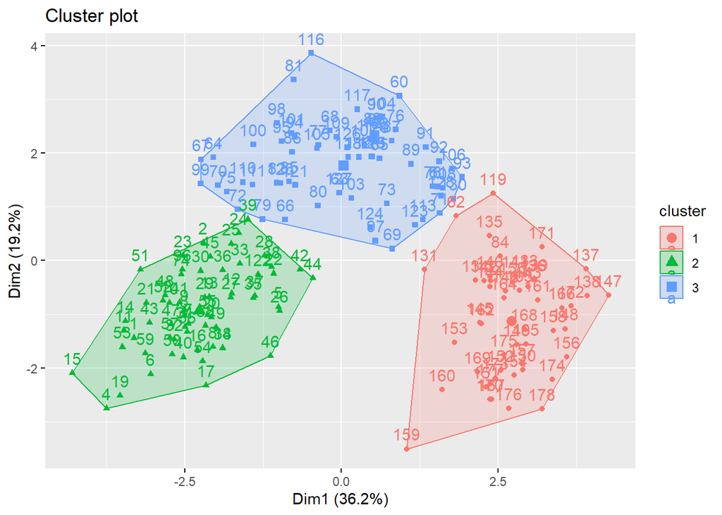

```r
fviz_cluster(kmeans.wines, data = wines.norm)
```

```r
print(kmeans.wines$centers)  # Display the centroid values of clusters
```

```
##      Alcohol Malic_Acid        Ash Ash_Alcanity   Magnesium Total_Phenols
## 1  0.1644436  0.8690954  0.1863726    0.5228924 -0.07526047   -0.97657548
## 2  0.8328826 -0.3029551  0.3636801   -0.6084749  0.57596208    0.88274724
## 3 -0.9234669 -0.3929331 -0.4931257    0.1701220 -0.49032869   -0.07576891
##    Flavanoids Nonflavanoid_Phenols Proanthocyanins Color_Intensity        Hue
## 1 -1.21182921           0.72402116     -0.77751312       0.9388902 -1.1615122
## 2  0.97506900          -0.56050853      0.57865427       0.1705823  0.4726504
## 3  0.02075402          -0.03343924      0.05810161      -0.8993770  0.4605046
##        OD280    Proline
## 1 -1.2887761 -0.4059428
## 2  0.7770551  1.1220202
## 3  0.2700025 -0.7517257
```